# Chess Elo Prediction — v3

**Multi-task neural network: BiLSTM with attention + static features + optional sequence autoencoder.**

Key improvements over v2:

- Time-control filter is **off by default** — the 600+0 filter was cutting 90%+ of games
- **Sequence autoencoder** (AE): compress 120-move sequences to 32-d vectors offline, so the main training loop runs at static-feature speed
- **KL-divergence soft target** inspired by the Ouzounis repo — model outputs a 40-bin rating distribution, not a single number
- **Elo-stratified WeightedRandomSampler** — fixes the chronic under-representation of high-Elo games
- Single-game inference cell at the bottom: paste any PGN and get a rating estimate
- All heavy steps are cached to disk so you never recompute them

## 0 — Imports

## 1 — Config

Everything in one place. Read the comments — they explain what to change for laptop vs GPU runs.

```
Device : cpu  |  AMP : False  |  CPU threads : 14
Sequential=False  AE=True  DistTarget=True
```

## 2 — Data Loading

```
Loaded 1,000,000 games in 33.1s
Removed 336,739 games by termination
Kept 534,045 games after TC filter (removed 126,381)
Elo — White 761–2812,  Black 758–2918
```

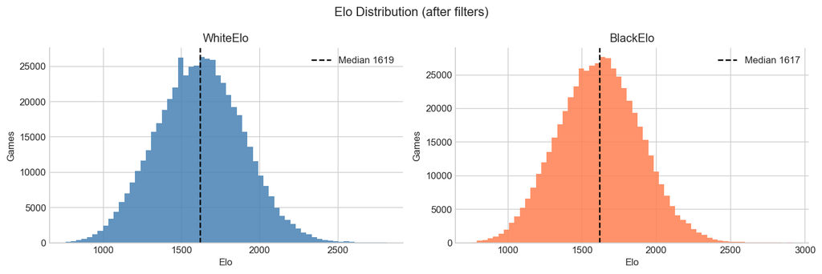

## 3 — Feature Extraction *(cached)*

Board and clock features are saved to `cache/` so they only recompute when you change the data.

```
Board features loaded from cache (35 cols)
Clock features loaded from cache (10 cols)
Full feature matrix: (534045, 69)
```

## 4 — Move Tokenisation

```
Dropped 7,049 short games
Vocab size : 10,199   Games ready: 526,996
```

## 5 — Soft Distribution Targets *(Ouzounis-style)*

Rather than regressing to a single number, the model learns to output a probability distribution over 40 Elo buckets (each 100 points wide). The ground truth for each player is a Gaussian centred on their actual Elo with σ=200, then discretised into those buckets. This captures the fact that a player's single-game performance is noisy around their true rating.

```
Distribution for 1600: peak bin=1550,  recovered Elo=1600
```

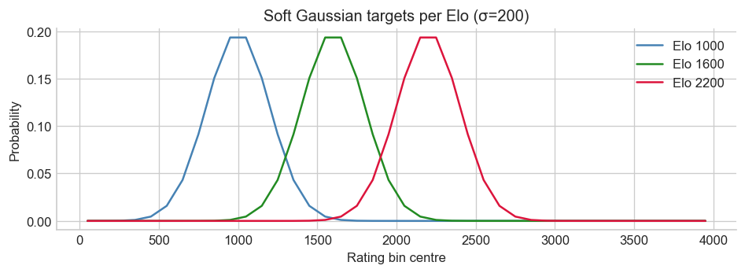

## 6 — Feature Selection, Split & Scaling

```
Static columns: 45
  [on] game_structure      (3 cols)
  [on] checks              (4 cols)
  [on] captures            (5 cols)
  [on] castling            (2 cols)
  [on] style               (9 cols)
  [on] engine_quality      (10 cols)
  [on] clock               (10 cols)
  [on] tc_meta             (2 cols)
Split — train:421,596  val:52,700  test:52,700
Scaling done (fit on train only)
```

## 7 — Sequence Autoencoder *(optional but recommended on CPU)*

The LSTM adds signal but is slow on CPU: a 200k-game run with `USE_SEQUENTIAL=True` takes hours. The autoencoder is the fix. We train it **once**, then use its **encoder half** to compress each game's move sequence into a `AE_LATENT_DIM`-dimensional vector and cache those vectors. The main model then just reads those cached vectors as extra static features — no recurrence at all during the main training loop.

**Install requirement:** `pip install torch` (already required). No extra package needed — the AE is a vanilla LSTM autoencoder built with PyTorch.

Set `USE_AE = True` in the Config cell to use this cell

```
Training sequence autoencoder...
  AE epoch 1/2  loss=6.4040
  AE epoch 2/2  loss=5.6988
AE embeddings saved: (526996, 32)
AE embeddings ready — 32 dims per game
```

## 8 — Dataset & DataLoaders

```
Building datasets...
  Built in 152.2s   total_static_dim=77
Batches/epoch: 3,294
```

## 9 — Model

Output head: when `USE_DIST_TARGET=True` the model predicts a 40-bin softmax distribution over rating ranges. Point estimate = weighted mean of that distribution. When False, direct Huber regression.

```
Trainable parameters: 1,354,481
```

## 10 — Training

```
Epoch  1/10  train 1.3106  val 1.0748  MAE W:209 B:211  lr 2.93e-04  44.5s
Epoch  2/10  train 1.0779  val 1.0860  MAE W:213 B:214  lr 2.73e-04  43.6s
Epoch  3/10  train 1.0280  val 1.0350  MAE W:204 B:205  lr 2.41e-04  43.9s
Epoch  4/10  train 1.0002  val 1.0409  MAE W:206 B:207  lr 2.02e-04  46.3s
Epoch  5/10  train 0.9821  val 1.0274  MAE W:204 B:204  lr 1.57e-04  45.0s
Epoch  6/10  train 0.9677  val 1.0164  MAE W:203 B:203  lr 1.13e-04  45.6s
Epoch  7/10  train 0.9589  val 0.9929  MAE W:199 B:200  lr 7.37e-05  42.2s
Epoch  8/10  train 0.9530  val 1.0282  MAE W:204 B:204  lr 4.22e-05  37.1s
Epoch  9/10  train 0.9471  val 1.0131  MAE W:202 B:202  lr 2.20e-05  36.1s
Early stopping at epoch 10
```

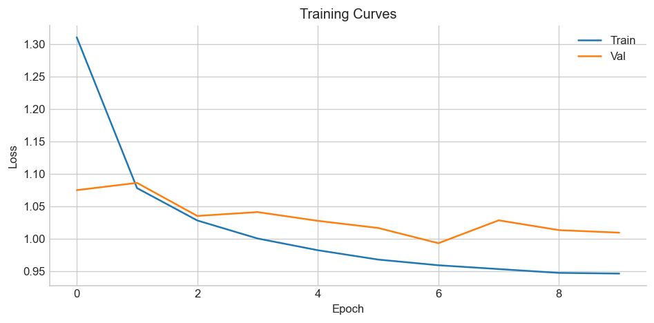

## 11 — Evaluation

```
Loaded: chess_elo_v3_1e+06.pth
MAE    — White: 200.5  Black: 199.2  Combined: 199.9
Median — White: 165.4  Black: 163.6
Within 100 Elo: 32.0%
Within 200 Elo: 58.5%
Within 300 Elo: 77.2%
```

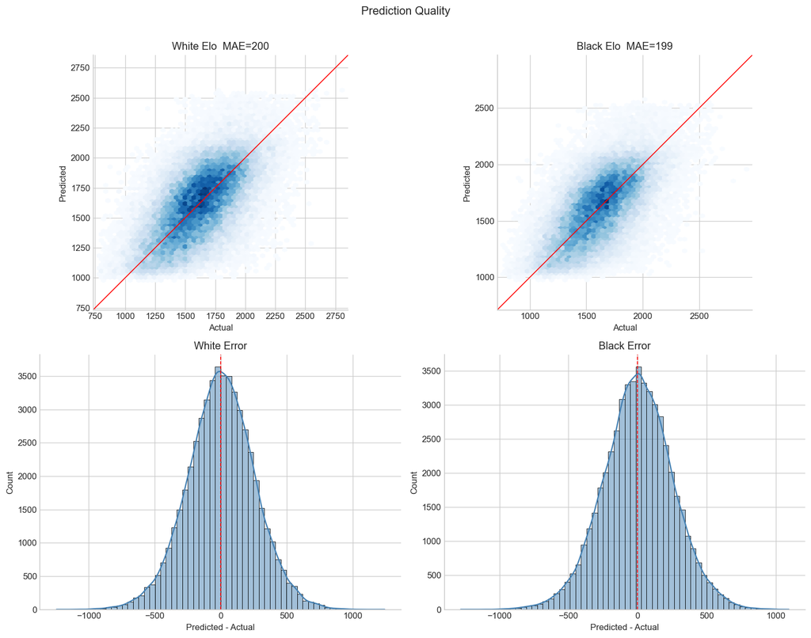

```
MAE by bracket:
----------------------------------------
           (0, 1000]  MAE=  285  n=895
        (1000, 1200]  MAE=  192  n=5,760
        (1200, 1400]  MAE=  194  n=16,143
        (1400, 1600]  MAE=  196  n=26,916
        (1600, 1800]  MAE=  191  n=28,615
        (1800, 2000]  MAE=  200  n=18,366
        (2000, 2200]  MAE=  237  n=6,784
        (2200, 2500]  MAE=  292  n=1,813
        (2500, 4000]  MAE=  338  n=108
```

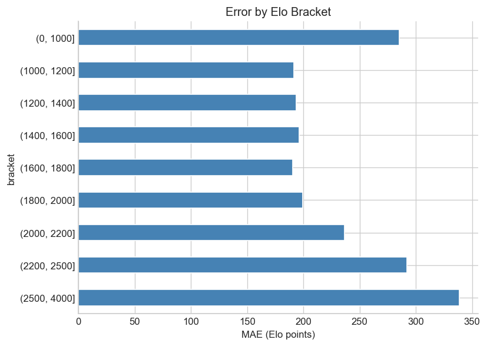

## 12 — Distribution Output Visualisation *(Ouzounis-inspired)*

One of the coolest things from the Ouzounis repo is showing how the predicted probability distribution changes move-by-move. We replicate that here: pick a test game and watch the distribution converge.

```
Distribution animation requires USE_DIST_TARGET=True and USE_SEQUENTIAL=True.
With the current config we just show the final distribution for a sample game.
```

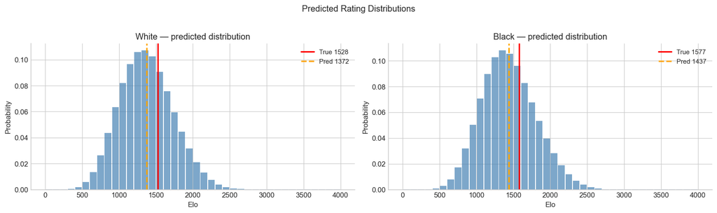

## 13 — Attention Heatmap

```
Attention heatmap requires USE_SEQUENTIAL=True.
```

## 14 — Latent Space Clustering

```
Running t-SNE on 3000 vectors...
```

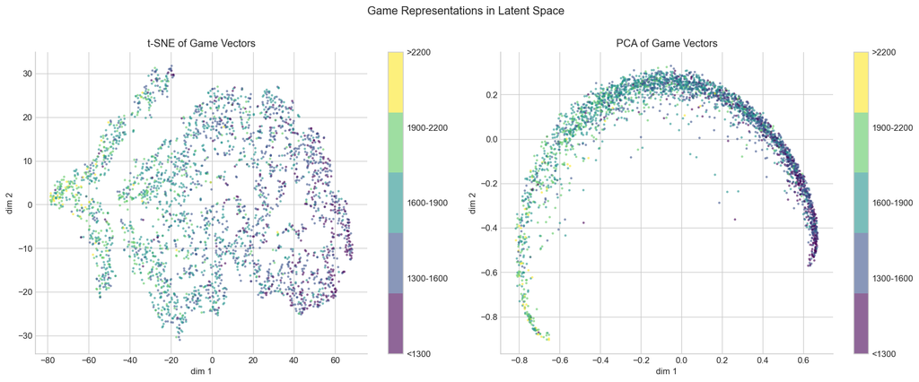

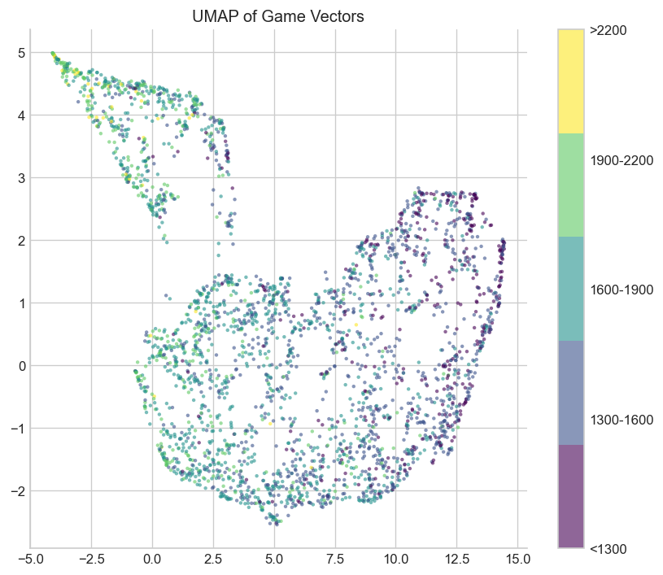

## 15 — Feature Importance & Ablation

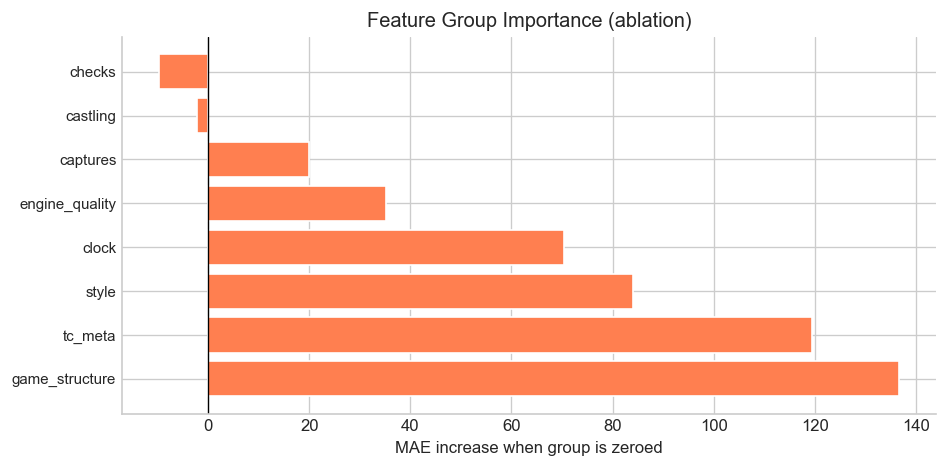

```
  game_structure      Δ=+136.6
  tc_meta             Δ=+119.5
  style               Δ=+84.0
  clock               Δ=+70.4
  engine_quality      Δ=+35.2
  captures            Δ=+19.9
  castling            Δ=-2.1
  checks              Δ=-9.7
```

## 16 — Progressive Elo Estimation

```
Progressive estimation requires USE_SEQUENTIAL=True.
```

## 17 — Opening Analysis (ECO codes)

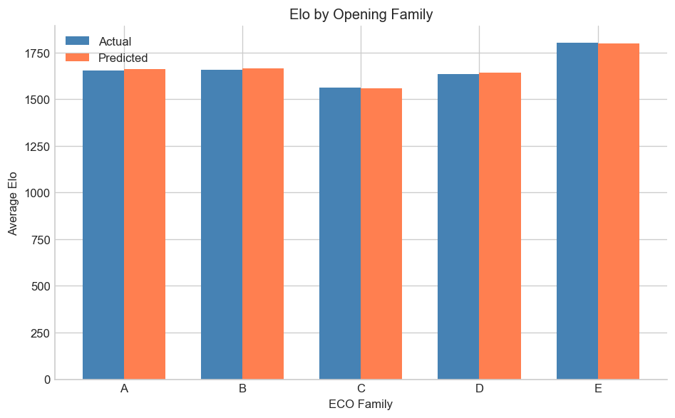

```
Top 5 highest-Elo ECO codes (min 10 games):
    E97  avg Elo: 2117  (n=12)
    B96  avg Elo: 2065  (n=10)
    E92  avg Elo: 2029  (n=12)
    A90  avg Elo: 2018  (n=10)
    E94  avg Elo: 2017  (n=13)

Bottom 5 lowest-Elo ECO codes (min 10 games):
    C20  avg Elo: 1424  (n=1838)
    C40  avg Elo: 1463  (n=1056)
    C22  avg Elo: 1468  (n=252)
    C49  avg Elo: 1475  (n=28)
    C46  avg Elo: 1485  (n=620)
```

## 18 — Anomaly Detection

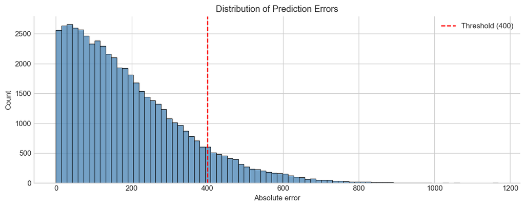

```
Flagged 5372 games > 400 Elo  (10.2%)

Top 15 OVERPERFORMERS
   Predicted      Actual      Diff
  --------------------------------
        2384        1216     +1168
        2481        1423     +1058
        2464        1486      +978
        2461        1495      +966
        2496        1546      +950
        2512        1574      +938
        2469        1539      +930
        2007        1082      +925
        2519        1598      +921
        2010        1094      +916
```

[output cut: 24 more lines]

## 19 — Single-Game Inference *(paste any PGN)*

Paste a PGN string into `EXAMPLE_PGN` and run the cell. The model will output predicted White and Black Elos along with the full probability distribution. Works without clocks — clock features just fill with NaN.

Copy a PGN from Lichess or chess.com (the 'Share' button), paste it below.

```
=============================================
  White Elo   predicted:  1786   actual: 1546
  Black Elo   predicted:  1753   actual: 1534
=============================================
```

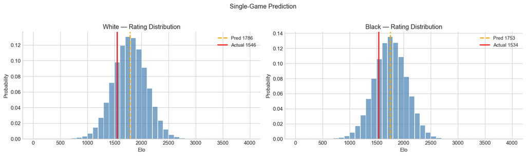

## 20 — Export